# DATA3888_2024 Lab: Week 3

Brain box data analytics

### Preparation and assumed knowledge

- Have a look at the **Lab** and make sure you have all packages installed on your computer.
- Able to write basic cross-validation R code.
- Work through Sections 1.1 and 1.2 of this lab, see Lab 1 and Week 2 lecture for suggestions.

### Aims

- To explore and process the .wav data and produce graphical summaries.
- Generate training data for left and right eye movement.
- Getting familiar with `while` loop and use it to generate statistics for streaming data.
- Please submit 3.2 for formative feedback.

**Note:** This is a very long lab, and some material here are hints for the interdisciplinary project. Again, all extension material won’t be assessed in the discipline quiz but may be of use for students who select this project as their interdisciplinary project.

R packages you need for this lab:

```
library(tidyverse)
library(tuneR)
library(devtools)
library(ggplot2)
library(tsfeatures)
```

# 1 Identify eye movement - single wave file

Two physics tutors have generated a series of data from the Spiker box. These signals are captured and saved as a WAV format. We will begin our exploration by looking at the data contained in the file `LRL_L3.wav`.

## 1.1 Reading the data

With the code below, we’ll read the `.wav` file using the `tuneR` package’s `readWave` function. We use two functions unique to the S4 class to retrieve information:

```r
## install.packages(tuneR)
library(tidyverse)
library(tuneR)
#library(devtools)
library(ggplot2)

waveSeq <- readWave("data/LRL_L3.wav")
waveSeq
slotNames(waveSeq)

# time (in second) of the sequencing
timeSeq <- seq_len(length(waveSeq))/waveSeq@samp.rate
```

- The function `slotNames` returns information about the components (termed slots) for a given object.
- To extract a specific slots of an S4 object, you use `@` such as `waveSeq@left`.

If you’re curious, you may learn all about the S4 object framework [here](http://adv-r.had.co.nz/S4.html), however it’s not needed for the lab.

**[a]** What are the dimensions of this `.wav` file?

**[b]** What kind of information do we have?

**[c]** How many measurements did we observe per second?

**Suggestions**

There are 72688 values and we have 10000 observations per second.

## 1.2 Simple visualisation

The code below is used to visualise the data using base R functions. The three eye movements in this file are displayed in the title of the file “LRL” denoting a left eye movement followed by a right and then left eye movement. Visually can you distinguish the pattern from left eye movement versus right eye movement?

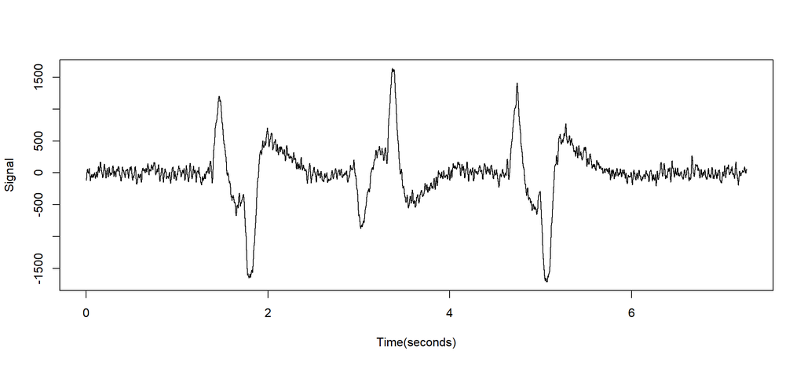

```r
plot(timeSeq, waveSeq@left, type = "l", ylab="Signal", xlab="Time(seconds)")
```

## 1.3 Generating training data

Even though we’ve been given the sequence of eye movements, we can’t accurately calculate the exact duration of eye movements. In section 1.2, we manually decide the time of the event. In this section, we use an algorithm to establish the time of the event, and to extract the data associated with left and right eye movements. The lecture notes and this lab provide one way of addressing this issue. You are encouraged to **generate your own solutions and share it with the class.**

```
## Input data from 1.1
## waveSeq = data from Spiker box
## timeSeq = sequence of time in seconds.

windowSize = 0.5
downSampleRate = 100
timeSeq[length(timeSeq)] - windowSize
ind = seq_len(which(timeSeq == timeSeq[length(timeSeq)] - windowSize) + 1)
ind = seq(1, length(ind), by = downSampleRate)
length(ind)
```

```r
windowSize = 0.5
downSampleRate = 100
ind = seq_len(which(timeSeq == timeSeq[length(timeSeq)] - windowSize) + 1)
ind = seq(1, length(ind), by = downSampleRate)
```

**[a]** Define the event of interest as any form of eye movement. A simple statistic to detect eye movement from the graph is to calculate the standard deviation of the signal in the moving window. Plot the standard deviation of 0.5 second windows across time. In order to minimise the computational time, only consider 1 out of every 100 windows.

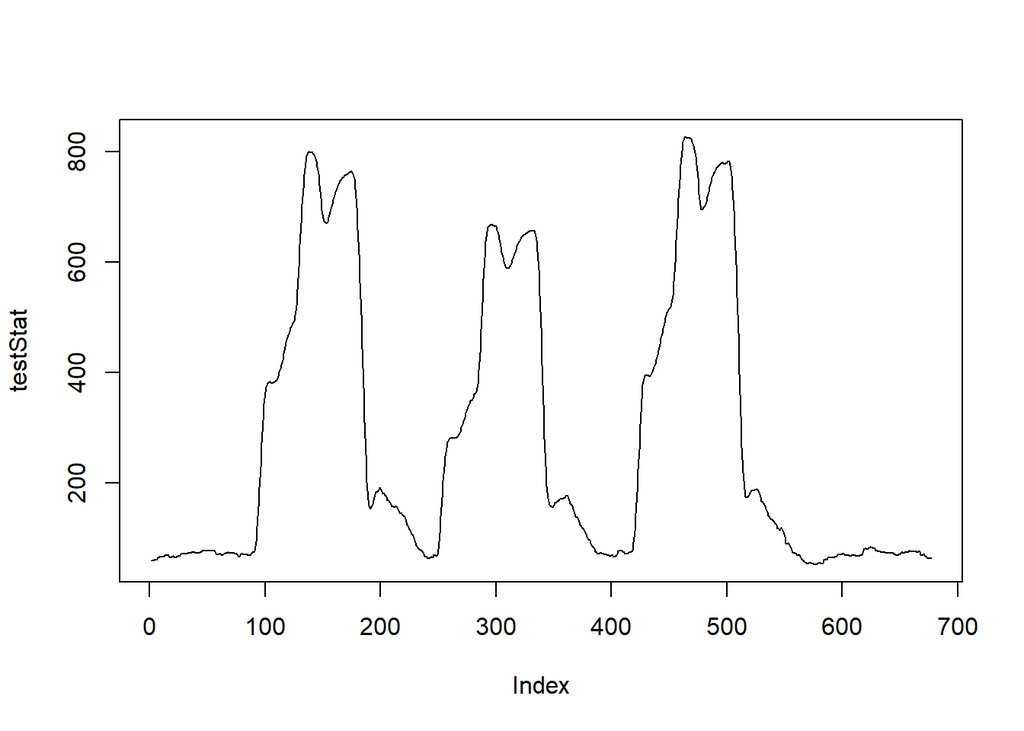

```r
## Construct a data frame (df)
df <- data.frame(Y = waveSeq@left,
                 time = timeSeq,
                 event_type = "none",
                 event_time = NA,
                 event_pos = NA)

testStat = rep(NA, length(ind))

for (i in 1:length(ind)) {
  # Calculate the standard deviation of signals within the window
  testStat[i] <- sd(df$Y[df$time >= df$time[ind[i]] & df$time < df$time[ind[i]] + windowSize])
}
plot(testStat, type="l")
```

**[b]** *Critical thinking question* - Consider additional statistics (eg maximum, zero crossings). A **zero-crossing** is a point where the sign of a mathematical function changes (e.g. from positive to negative) in a graph. Here we can check the number of zero-crossings in the window. Can you expect the “case with eye movement” cycles to have more or less zero-crossings ? Plot three different statistics on the same graph (e.g. SD, maximum, zero cross over) and determine which statistics you prefer and why? Discuss it with your peers.

```
## Define a local window
Y_subset <- Y[df$time >= df$time[ind[i]] & df$time < df$time[ind[i]] + windowSize]

## Within a local window, calculate the number of zero-crossings within the window
testStat0[i] <- sum(Y_subset[1:(length(Y_subset) - 1)] * Y_subset[2:(length(Y_subset))] <= 0)
```

**Suggestions**

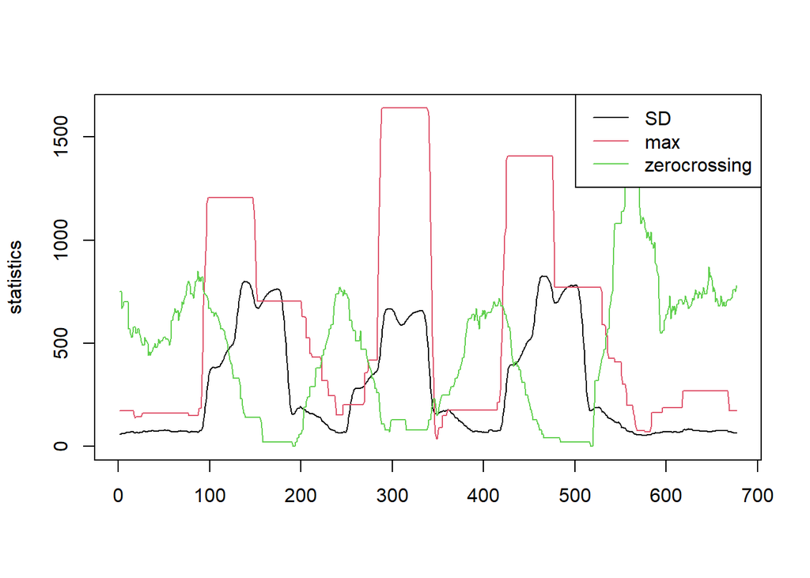

```r
testStat = testStat1 = testStat2 = rep(NA, length(ind))
stat_event <- rep(NA, length(ind))

for (i in 1:length(ind)) {
  Y_subset <- df$Y[df$time >= df$time[ind[i]] & df$time < df$time[ind[i]] + windowSize]

  # Calculate the standard deviation of signals within the window
  testStat[i] <- sd(Y_subset)
  testStat1[i] = max(Y_subset)
  testStat2[i] = sum(Y_subset[1:(length(Y_subset) - 1)] * Y_subset[2:(length(Y_subset))] <= 0)
}

matplot(cbind(testStat, testStat1, testStat2*10), type="l", lty=1, ylab="statistics")
legend("topright", c("SD", "max", "zerocrossing"), lty=1, col=1:3)
```

## 1.4 Classify eye movement

Looking at the graph, use a simple threshold to classify eye movement.

```
predictedEvent <- which(testStat < thresholdEvents)
```

## 1.5 Function

Build a classification model to classify event (eye movement) and non-event (no movement). Write a function `eye_movement_ZC` that identifies the eye movement. The input should be the wave values and times, and the output should be the times corresponding to events. Below is some skeleton code:

```
eye_movement_ZC = function(Y, time,
windowSize = 0.5,
thresholdEvents = 20,
downSampleRate = 50) {

## down sample
ind = seq_len(which(time == time[length(time)] - windowSize) + 1)
ind = seq(1, ind[length(ind)], by = downSampleRate)

## time vector for middle of each window
timeMiddle <- time[ind] + windowSize/2
testStat = rep(NA, length(ind))

## Calculate zero-crossings
for (i in 1:length(ind)) {
< write your own code>

}

## Using threshold to determine eye movement intervals

}

## Test out your function
eye_movement_ZC(Y = waveSeq@left, time = timeSeq)$predictedInterval
```

**Suggestions**

```r
eye_movement_ZC = function(Y, time,
                           windowSize = 0.5,
                           thresholdEvents = 20,
                           downSampleRate = 50) {

  ## down sample
  ind = seq_len(which(time == round(time[length(time)] - windowSize, 4)) + 1)
  ind = seq(1, ind[length(ind)], by = downSampleRate)

  ## time vector for middle of each window
  timeMiddle <- time[ind] + windowSize/2
  testStat = rep(NA, length(ind))

  ## calculate zero-crossings
  for (i in 1:length(ind)) {
    Y_subset <- Y[time >= time[ind[i]] & time < time[ind[i]] + windowSize]
    testStat[i] <- sum(Y_subset[1:(length(Y_subset) - 1)] * Y_subset[2:(length(Y_subset))] <= 0)
  }

  ## using threshold to determine eye movement intervals
  predictedEvent <- which(testStat < thresholdEvents)
  eventTimes <- timeMiddle[predictedEvent] # map back to the time of this
  gaps <- which(diff(eventTimes) > windowSize)

  ## estimate event_time_interval
  event_time_interval <- min(eventTimes)
  for (i in 1:length(gaps)) {
    event_time_interval <- append(event_time_interval,
                                  c(eventTimes[gaps[i]],
                                    eventTimes[gaps[i] + 1]))
  }
  event_time_interval <- append(event_time_interval, max(eventTimes))
  event_time_interval <- matrix(event_time_interval, ncol = 2, byrow = TRUE)

  predictedEventTimes <- rep(FALSE, length(Y))
  for (i in 1:nrow(event_time_interval)) {
    predictedEventTimes[event_time_interval[i, 1] <= time & event_time_interval[i, 2] >= time] <- TRUE
  }

  num_event <- length(gaps) + 1
  return(list(num_event = num_event,
              predictedEventTimes = predictedEventTimes,
              predictedInterval = event_time_interval))
}

## Testout the function
eye_movement_ZC(Y = waveSeq@left, time = timeSeq)$predictedInterval
```

# 2 Extracting signals from multiple files

In Section 1.5, we have written a function to identify an eye-movement event. Using this function, we are in a position to create a training data for left- vs right- eye movement. We will do this in 4 steps:

- Step 1: Reading in multiple files.
- Step 2: Identify event and extract signals for all files.
- Step 3: Filter low quality data.
- Step 4: Extract signals for all 24 files.

## 2.1 Data input (extension)

Read all the short sequence data generated by the Physics tutor Louis and store it as a list object. The function `lapply` apply a function over a list and returns a list of the same length.

```
dir_short = <write down the data directory>
all_files_short <- list.files(dir_short)

wave_file_short <- list()
for (i in all_files_short) {
  wave_file_short[[i]] <- readWave(file.path(dir_short, i))
}
```

**Suggestions**

We assume the data are in the folder `data/Spiker_box_Louis/Short`.

```r
dir_short <- "data/Spiker_box_Louis/Short"
all_files_short <- list.files(dir_short)

wave_file_short <- list()
for (i in all_files_short) {
  ## cat(paste0(i, "...", "\n"))
  wave_file_short[[i]] <- tuneR::readWave(file.path(dir_short, i))
}
```

## 2.2 Extract signals (extension)

You may also decide to use the longer WAV files to generate this dataset. This part is important for the interdisciplinary project. You will need to write your own `extractSignal` function.

```
extractSignal = function(limits, seq, xtime) {
  index = (xtime > limits[1]) & (xtime < limits[2])
  return(seq[index])
}
```

```
wave_seq_short = list()
for(i in 1:length(wave_file_short)) {
  print(i)
  wave_file = wave_file_short[[i]]
  Y = wave_file@left
  xtime = seq_len(length(wave_file))/wave_file@samp.rate
  cut_result = eye_movement_ZC(Y, xtime)
  wave_seq_short[[i]] = apply(cut_result$predictedInterval, 1, extractSignal, Y, xtime)
}
```

## 2.3 Simple classifier

Looking at the graph from section 1.2, it is very obvious that a left-eye movement is consistent with a strong positive signal followed by a strong negative signal. In contrast, the right-eye movement is consistent with a strong negative signal followed by a strong positive signal. This discrimination rule can be easily captured in a classifier without any feature selection or model training.

```
LR_detection = function(seq) {
  maxval = which.max(seq, na.rm=TRUE)
  minval = which.min(seq, na.rm=TRUE)
  movement = ifelse(maxval < minval,  "L", "R")
  return(movement)
}
```

## 2.4 Feature extraction

We encourage you to build your own training dataset from section 2.1 and 2.2. For your convenience, we’ve created a pre-made collection of training data `wave_seq_short_list_zoe.rds` and its corresponding labels `wave_label_short_results.rds` for you to use in this lab. In this section, we will be using the function `tsfeatures` to extract various features from time-series data. You are also able to create any features (metrics) that you believe are important.

```
library(tsfeatures)

wave_seq_short = readRDS("wave_seq_short_list_zoe.rds")
wave_label_short = readRDS("wave_label_short_results.rds")
Y_list = unlist(wave_seq_short, recursive=FALSE)
Y_lab = unlist(wave_label_short)

# help(tsfeatures)
Y_features <- tsfeatures(Y_list, c("lumpiness","flat_spots","crossing_points"))
Y_features <- tsfeatures(Y_list, c("mean","var"), scale=FALSE, na.rm=TRUE)
```

**Suggestions**

```r
library(tsfeatures)
wave_seq_short = readRDS("data/wave_seq_short_list_zoe.rds")
wave_label_short = readRDS("data/wave_label_short_results.rds")
Y_list = unlist(wave_seq_short, recursive=FALSE)
Y_lab = unlist(wave_label_short)

Y_features <- cbind(
  tsfeatures(Y_list,
             c("acf_features","entropy","lumpiness",
               "flat_spots","crossing_points")),
  tsfeatures(Y_list, "max_kl_shift", width=48),
  tsfeatures(Y_list,
             c("mean","var"), scale=FALSE, na.rm=TRUE),
  tsfeatures(Y_list,
             c("max_level_shift","max_var_shift"), trim=TRUE))
```

## 2.5 Basic classifier - KNN

Perform k-nearest neighbours on the data with $k=3$ and estimate the cross-validation (CV) accuracy using repeated 5-fold CV with 50 repeats. Hint: you can modify the code from Section 1 in Lab 1.

```
X = as.matrix(Y_features)
y = Y_lab

cvK = 5  # number of CV folds
cv_50acc5_knn = cv_acc5 = c()
<write your own>
```

```r
X = as.matrix(Y_features)
y = Y_lab

cvK = 5  # number of CV folds
cv_50acc5_knn = cv_acc5 = c()
for (i in 1:50) {
  cvSets = cvTools::cvFolds(nrow(X), cvK)  # permute all the data, into 5 folds

  cv_acc = NA  # initialise results vector
  for (j in 1:cvK) {
    test_id = cvSets$subsets[cvSets$which == j]
    X_test = X[test_id, ]
    X_train = X[-test_id, ]
    y_test = y[test_id]
    y_train = y[-test_id]
    fit = class::knn(train = X_train, test = X_test, cl = y_train, k = 3)
    cv_acc5[j] = table(fit, y_test) %>% diag %>% sum %>% `/`(length(y_test))
  }
  cv_50acc5_knn <- append(cv_50acc5_knn, mean(cv_acc5))
}

boxplot(cv_50acc5_knn, horizontal = TRUE, xlab="Accuracy")
```

[output not shown]

## 2.6 Classifier - Extension (for interdisciplinary project)

For an additional challenge, you can treat this as a multi-class classification problem by including “no-movement”. That is predicting between `left movement`, `right movement` and `no movement`. You might like to include an approach that incorporates semi-supervised learning, such as `adaptive sampling` (discussed in Week 6).

# 3 Streaming classifier

## 3.1 While loop practice

A `while` loop refers to the repetition of a collection of “code blocks” or “expressions” until a certain condition is met. In R, the syntax of a `while` loop is:

```
while (condition) {
  expression
}
```

As long as the `condition` is `TRUE` the `expression` is evaluated. Once the condition is `FALSE`, control is transferred outside the loop.

**[a]** Write a procedure to print the first 10 even numbers using a `while` loop.

**Suggestions**

```r
i = 2
while(i <= 2*10)
  {
    print(i)
    i = i + 2
  }
```

**[b]** Create a `while` Loop that prints out a sequence of random, standard normal numbers until it exceeds 1.

**Suggestions**

```r
i = 0 ## initialise i
while(i < 1)
  {
    i = rnorm(1)
    print(i)
  }
```

## 3.2 Moving window

Use while loop to calculate the standard deviation of the signal for a given window under a streaming condition where the function will take a sequence of signals as an input. Visualise this information and submit it for **formative feedback**. Consider playing with the increment and see the impact.

```
 increment = window_size*1.5
 increment = window_size
 increment = window_size/3
 increment = window_size/10
```

Some code suggestions:

```
  waveSeq <- readWave("data/LRL_L3.wav")

  window_size = waveSeq@samp.rate
  increment = window_size/3
  Y = waveSeq@left

  statSignal = c(NA,NA)
  lower_interval = 1
  xtime = seq_len(length(waveSeq))/waveSeq@samp.rate
  max_time = max(xtime)*window_size

  while(max_time > lower_interval + window_size)
  {
    upper_interval = <write your own code>
    interval = Y[lower_interval:upper_interval]
    midpoint = (lower_interval + upper_interval)/2
    calstat = <write your own code>
    statSignal = rbind(statSignal, c(midpoint, calstat))
    lower_interval = <write your own code>
  } ## end while
```

**Suggestions**

```r
  waveSeq <- readWave("data/LRL_L3.wav")

  window_size = waveSeq@samp.rate
  increment = window_size/3
  Y = waveSeq@left

  statSignal = c(NA,NA)
  lower_interval = 1
  xtime = seq_len(length(waveSeq))/waveSeq@samp.rate
  max_time = max(xtime)*window_size

  while(max_time > lower_interval + window_size)
  {
    upper_interval = lower_interval + window_size
    interval = Y[lower_interval:upper_interval]
    midpoint = (lower_interval + upper_interval)/2
    calstat = sd(interval)
    statSignal = rbind(statSignal, c(midpoint, calstat))
    lower_interval = lower_interval + increment
  } ## end while

df_line <- data.frame(Y)
df_line$x <- c(1:nrow(df_line))
df_point <- data.frame(statSignal[-1, ])

ggplot() +  geom_line(data =df_line, aes(x = x ,  y = Y) ) +
  geom_point( data = df_point, aes(x= X1, y = X2) , colour  = "red", size = 4, shape = 18) +
  geom_line( data = df_point, aes(x= X1, y = X2), colour = "red"  ) + xlab("Index")
```

## 3.3 Streaming classifier (Assignment 1)

*One of the assignment 1 questions will be based on the following task.*

- Build a classification rule for detecting {L, R} under a streaming condition where the function will take a sequence of signal as the input. Note, this is slightly different to detecting {L, R} for a given sequence.
- Estimate the accuracy of your classifier. Is your value reasonable?
- Does the length of the sequence impact on the classification accuracy?

```
streaming_classifier = function(wave_file,
                                window_multiplier = 1) {

  window_size = wave_file@samp.rate*window_multiplier
  increment = window_size/3

  Y = wave_file@left
  xtime = seq_len(length(Y))/wave_file@samp.rate
  predicted_labels = c()
  window_lb = 1
  max_time = length(Y)

  while(max_time > window_lb + window_size) {

    window_ub = window_lb + window_size
    window = Y[window_lb:window_ub]

    event = <event detection>

    if (event) {
      predicted = <LR prediction>
      predicted_labels = c(predicted_labels, predicted)
      window_lb = window_lb + window_size
    } else {
      window_lb = window_lb + increment
    }
  }
  return(paste(predicted_labels, collapse = ""))
}
```